# Airline Project

## Data Manipulation

```r
library(ggplot2) # Data visualization
library(readr) # CSV file I/O, e.g. the read_csv function
library(dplyr)
library(stringr)
system("ls ../input")
data <- read_csv("F:/Documents/Fleet Data.csv")
```

```r
#making the data easier to deal with
colnames(data) <- c("parent_airline","airline","aircraft_type","current","future","historic","total","orders","unit_cost","total_cost","average_age")
#nrow(data)
data$total_cost <- as.numeric(gsub(",","",substring(data$total_cost,2)))
data$unit_cost <- as.numeric(gsub(",","",substring(data$unit_cost,2)))
data$plane_brand <- word(data$aircraft_type,1)
data <- data %>% mutate(newcost=ifelse(!is.na(orders),orders*unit_cost,0))
```

```r
#adding flags for airbus and boeing
data <- data %>% mutate(airbus=ifelse(plane_brand=="Airbus",ifelse(is.na(current),0,current),0))
data <- data %>% mutate(boeing=ifelse(plane_brand=="Boeing",ifelse(is.na(current),0,current),0))
data <- data %>% mutate(embraer=ifelse(plane_brand=="Embraer",ifelse(is.na(current),0,current),0))
data <- data %>% mutate(bombardier=ifelse(plane_brand=="Bombardier",ifelse(is.na(current),0,current),0))
data <- data %>% mutate(mitsubishi=ifelse(plane_brand=="Mitsubishi",ifelse(is.na(current),0,current),0))
data <- data %>% mutate(embraer=ifelse(plane_brand=="Embraer",ifelse(is.na(current),0,current),0))
data <- data %>% mutate(comac=ifelse(plane_brand %in% c("COMAC","comac"),ifelse(is.na(current),0,current),0))
data <- data %>% mutate(mcdonnell=ifelse(plane_brand=="McDonnell",ifelse(is.na(current),0,current),0))
data <- data %>% mutate(canadair=ifelse(plane_brand=="Canadair",ifelse(is.na(current),0,current),0))
data <- data %>% mutate(atr=ifelse(plane_brand=="ATR",ifelse(is.na(current),0,current),0))
```

```r
#table(data$plane_brand)

#adding flags for future airbus and future boeing
data <- data %>% mutate(airbus_future=ifelse(plane_brand=="Airbus",ifelse(is.na(orders),0,orders),0))
data <- data %>% mutate(boeing_future=ifelse(plane_brand=="Boeing",ifelse(is.na(orders),0,orders),0))

#The below list is not exhaustive.
lowcostcarriers<- c("AirAsia X","Gol Linhas Aereas","Azul","Tigerair Australia","Volaris","Interjet","Spirit Airlines","Frontier Airlines","Allegiant Air","WestJet","Air Canada Rouge","FlyDubai","Up","Monarch Airlines","Jet2","Flybe","Vueling","Iberia Express","Pobeda","Transavia","Germanwings","Eurowings","easyJet","Wizz Air","Lion Air","IndiGo", "Southwest Airlines", "RyanAir","AirAsia","LionAir","JetBlue Airways","Norwegian Air","WestJet","Pegasus Airlines","Flybe","SpiceJet","Air Arabia Egypt","Air Arabia Maroc","Air Cairo","Jambojet Limited","Mango","China United Airlines","Spring Airlines","Cebu Pacific Air","Jetstar Airways","AirAsia India","AirAsia Japan")
data$type <- NA
data <- data %>% mutate(type=ifelse(airline %in% lowcostcarriers,"Low Cost","Traditional"))

head(data %>% filter(type=="Low Cost"))
length(unique(data$airline))
length(unique(data$parent_airline))
```

| parent_airline | airline | aircraft_type | current | future | historic | total | orders | unit_cost | total_cost | ... | embraer | bombardier | mitsubishi | comac | mcdonnell | canadair | atr | airbus_future | boeing_future | type |
| --- | --- | --- | --- | --- | --- | --- | --- | --- | --- | --- | --- | --- | --- | --- | --- | --- | --- | --- | --- | --- |
| Aeroflot | Pobeda | Boeing 737 | 12 | NA | NA | 12 | NA | 74 | 888 | ... | 0 | 0 | 0 | 0 | 0 | 0 | 0 | 0 | 0 | Low Cost |
| Air Arabia | Air Arabia Egypt | Airbus A320 | 1 | NA | 2 | 3 | NA | 98 | 98 | ... | 0 | 0 | 0 | 0 | 0 | 0 | 0 | 0 | 0 | Low Cost |
| Air Arabia | Air Arabia Maroc | Airbus A320 | 5 | NA | 5 | 10 | NA | 98 | 490 | ... | 0 | 0 | 0 | 0 | 0 | 0 | 0 | 0 | 0 | Low Cost |
| Air Canada | Air Canada Rouge | Airbus A319 | 20 | NA | NA | 20 | NA | 90 | 1792 | ... | 0 | 0 | 0 | 0 | 0 | 0 | 0 | 0 | 0 | Low Cost |
| Air Canada | Air Canada Rouge | Airbus A321 | 5 | NA | NA | 5 | NA | 115 | 575 | ... | 0 | 0 | 0 | 0 | 0 | 0 | 0 | 0 | 0 | Low Cost |
| Air Canada | Air Canada Rouge | Boeing 767 | 19 | NA | NA | 19 | 6 | 187 | 3551 | ... | 0 | 0 | 0 | 0 | 0 | 0 | 0 | 0 | 6 | Low Cost |

280

117

## Let's look for largest airlines

```r
#Let's find largest airlines

#lets find out which airlines have the largest fleets
airline_fleet <- data %>% group_by(airline) %>% summarise(fleet=sum(current,na.rm=TRUE),historic=sum(historic,na.rm=TRUE),orders=sum(orders,na.rm=TRUE),ratio=100*(orders/fleet),current_fleet_cost=sum(total_cost,na.rm=TRUE),value_per_fleet_unit=current_fleet_cost/fleet)
airline_fleet <- airline_fleet %>% mutate(type=ifelse(airline %in% lowcostcarriers,"Low Cost","Traditional"))
head(airline_fleet %>% arrange(desc(fleet)))
```

| airline | fleet | historic | orders | ratio | current_fleet_cost | value_per_fleet_unit | type |
| --- | --- | --- | --- | --- | --- | --- | --- |
| American Airlines | 928 | 850 | 287 | 30.92672 | 103892 | 111.95259 | Traditional |
| Delta Airlines | 855 | 589 | 268 | 31.34503 | 79171 | 92.59766 | Traditional |
| United Airlines | 730 | 664 | 173 | 23.69863 | 90037 | 123.33836 | Traditional |
| Southwest Airlines | 718 | 195 | 284 | 39.55432 | 53118 | 73.98050 | Low Cost |
| China Southern Airlines | 522 | 175 | 115 | 22.03065 | 61370 | 117.56705 | Traditional |
| China Eastern Airlines | 451 | 186 | 233 | 51.66297 | 51511 | 114.21508 | Traditional |

#### We see that the US leads, followed by China

#### Let's look for airline companies that exhibit Growth

```r
#let's find out which airlines have the most orders
head(airline_fleet %>% arrange(desc(orders)))
```

| airline | fleet | historic | orders | ratio | current_fleet_cost | value_per_fleet_unit | type |
| --- | --- | --- | --- | --- | --- | --- | --- |
| Lion Air | 113 | 45 | 425 | 376.10619 | 9342 | 82.67257 | Low Cost |
| IndiGo | 124 | 16 | 420 | 338.70968 | 12152 | 98.00000 | Low Cost |
| AirAsia | 77 | 66 | 401 | 520.77922 | 7546 | 98.00000 | Low Cost |
| American Airlines | 928 | 850 | 287 | 30.92672 | 103892 | 111.95259 | Traditional |
| Southwest Airlines | 718 | 195 | 284 | 39.55432 | 53118 | 73.98050 | Low Cost |
| Delta Airlines | 855 | 589 | 268 | 31.34503 | 79171 | 92.59766 | Traditional |

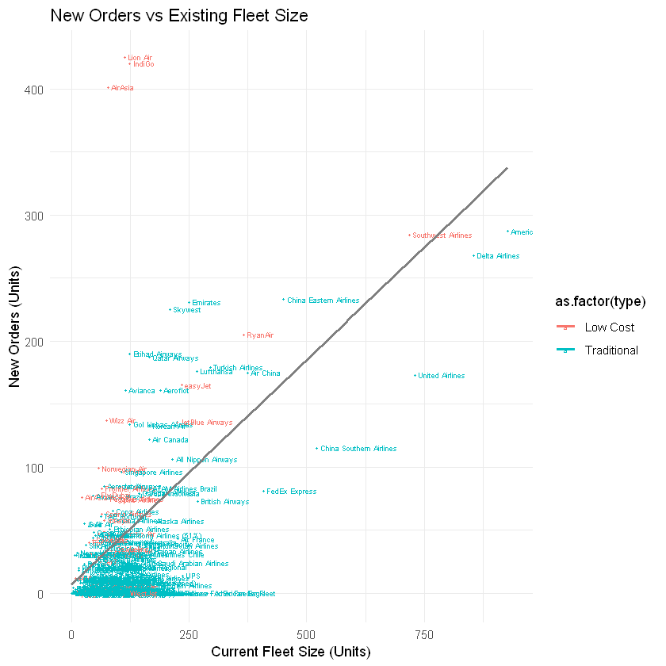

```r
#ratio of orders vs current fleet for fleets more than 10
#head(airline_fleet %>% filter(fleet>10) %>% arrange(desc(ratio)))

#largest fleet costs carriers
#head(airline_fleet %>% filter(fleet>10) %>% arrange(desc(current_fleet_cost)))

#plot current vs future
g <- ggplot(airline_fleet,aes(x=fleet,y=orders,label=airline,color=as.factor(type)))+geom_point(size=0.5) +geom_text(size=2,hjust=0,vjust=0,nudge_x=7,nudge_y=-2)+ theme_minimal()
#geom_text(aes(label=rownames(airline_fleet)))
g + geom_smooth(aes(color=NA),method=lm,se=FALSE) + ggtitle("New Orders vs Existing Fleet Size")+labs(x="Current Fleet Size (Units)",y="New Orders (Units)")
```

#### You can see that Lion Air, IndiGo, and Air Asia are clear outliers

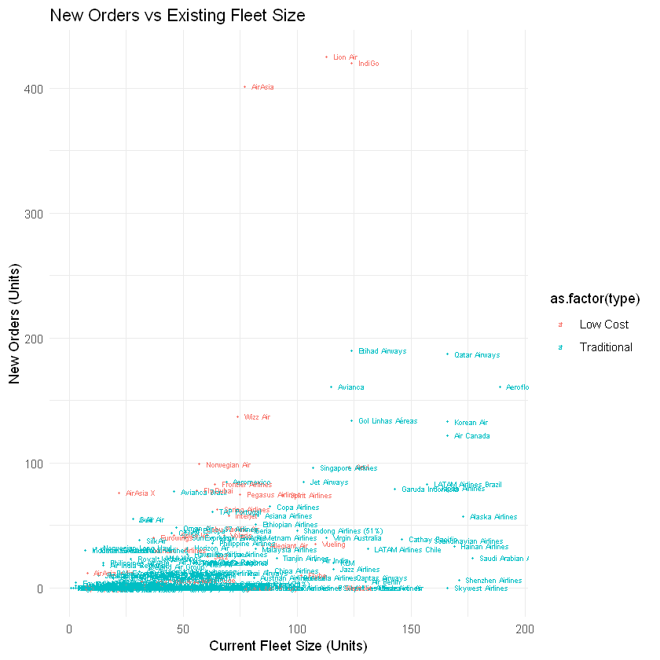

```r
g <- ggplot(airline_fleet %>% filter(fleet<=200),aes(x=fleet,y=orders,label=airline,color=as.factor(type)))+geom_point(size=0.5) +geom_text(size=2,hjust=0,vjust=0,nudge_x=3,nudge_y=-2)+ theme_minimal()
#geom_text(aes(label=rownames(airline_fleet)))
g  + ggtitle("New Orders vs Existing Fleet Size")+labs(x="Current Fleet Size (Units)",y="New Orders (Units)")
```

#### When we pare down to fleet size < 200 units, the cluster becomes more clear

#### Let's look for the most popular planes (based on orders), you will see the Boeing 737 and 2nd place

| aircraft_type | orders | cost | new |
| --- | --- | --- | --- |
| Airbus A320 | 2506 | 98 | old |
| Boeing 737 | 2300 | 74 | old |
| Airbus A321 | 1090 | 115 | old |
| Boeing 787 Dreamliner | 454 | 265 | new |
| Boeing 777 | 423 | 295 | old |
| Airbus A350 XWB | 393 | 312 | new |

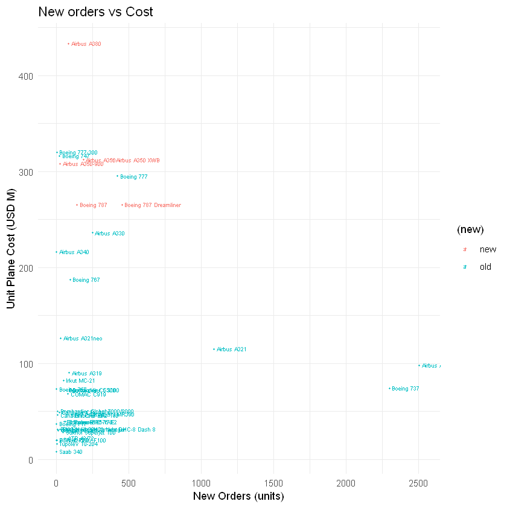

```r
neworders <-data %>% filter(!is.na(orders)) %>% filter(orders>0) %>% group_by(aircraft_type) %>% summarise(orders=sum(orders),cost=mean(unit_cost))

newplanes<-c("Airbus A380","Airbus A350","Airbus A350 XWB","Airbus A350-900","Boeing 787","Boeing 787 Dreamliner")
neworders <- neworders %>% mutate(new=ifelse(aircraft_type%in%newplanes,"new","old"))

head(neworders %>% arrange(desc(orders)))

ggplot(neworders,aes(x=orders,y=cost,label=aircraft_type,color=(new)))+geom_point(size=0.5)+geom_text(size=2,hjust=0,vjust=0,nudge_x=20,nudge_y=-2)+ggtitle("New orders vs Cost")+labs(x="New Orders (units)",y="Unit Plane Cost (USD M)")+theme_minimal()
```

##### It also demonstrates that newer planes sell less.

##### I would posit that the market looks for low-cost carriers at cost efficiency.

##### Let's compare the Boeing 737 to an Airbus.

```r
buyingcheap <- data %>% filter(!is.na(orders)) %>% filter(orders>0) %>% filter(aircraft_type %in% c("Airbus A320","Boeing 737")) %>% group_by(airline) %>% summarise(orders=sum(orders))
head(buyingcheap %>% arrange(desc(orders)))
```

| airline | orders |
| --- | --- |
| Lion Air | 425 |
| IndiGo | 400 |
| AirAsia | 301 |
| Southwest Airlines | 284 |
| RyanAir | 205 |
| China Eastern Airlines | 171 |

```r
buying380 <- data %>% filter(!is.na(orders)) %>% filter(orders>0) %>% filter(aircraft_type=="Airbus A380") %>% group_by(airline) %>% summarise(orders=sum(orders))
head(buying380 %>% arrange(desc(orders)))
```

| airline | orders |
| --- | --- |
| Emirates | 54 |
| China Southern Airlines | 17 |
| Singapore Airlines | 5 |
| Qatar Airways | 4 |
| All Nippon Airways | 3 |
| Etihad Airways | 2 |

```r
buying787DL <- data %>% filter(!is.na(orders)) %>% filter(orders>0) %>% filter(aircraft_type=="Boeing 737") %>% group_by(airline) %>% summarise(orders=sum(orders))
head(buying787DL %>% arrange(desc(orders)))
```

| airline | orders |
| --- | --- |
| Southwest Airlines | 284 |
| RyanAir | 205 |
| Lion Air | 204 |
| Gol Linhas Aéreas | 134 |
| American Airlines | 121 |
| United Airlines | 103 |

#### We see who's buying the Boeing 737 above

```r
current_aircrafts <- data %>% filter(!is.na(current)) %>% filter(current>0) %>% group_by(plane_brand) %>% summarise(current=sum(current),cost=sum(total_cost,na.rm=TRUE))
head(current_aircrafts %>% arrange(desc(current)))
```

| plane_brand | current | cost |
| --- | --- | --- |
| Boeing | 8773 | 1179299 |
| Airbus | 7440 | 983031 |
| Embraer | 1370 | 52968 |
| Canadair | 1039 | 41590 |
| De | 525 | 16407 |
| ATR | 491 | 10784 |

## Plane manufacturers and mix by airline

#### Seems Boeing is largely responsible for today's fleets

```r
bycompany <- data %>% group_by(airline) %>% summarise(total=sum(current,na.rm=TRUE),airbus=sum(airbus),boeing=sum(boeing),airbusper=round(100*airbus/total),boeingper=round(100*boeing/total),airbusadd=sum(airbus_future),boeingadd=sum(boeing_future),newtotal=total+airbusadd+boeingadd,newairbusper=round(100*(airbus+airbusadd)/newtotal))

bycompany <- bycompany %>% mutate(type=ifelse(airline %in% lowcostcarriers,"Low Cost","Traditional"))
head(bycompany %>% filter(total> 300) %>% arrange(desc(boeingper)))
head(bycompany %>% filter(total> 300) %>% arrange(desc(airbusper)))
```

| airline | total | airbus | boeing | airbusper | boeingper | airbusadd | boeingadd | newtotal | newairbusper | type |
| --- | --- | --- | --- | --- | --- | --- | --- | --- | --- | --- |
| RyanAir | 366 | 0 | 366 | 0 | 100 | 0 | 205 | 571 | 0 | Low Cost |
| Southwest Airlines | 718 | 0 | 718 | 0 | 100 | 0 | 284 | 1002 | 0 | Low Cost |
| United Airlines | 730 | 156 | 574 | 21 | 79 | 3 | 146 | 879 | 18 | Traditional |
| Delta Airlines | 855 | 180 | 483 | 21 | 56 | 119 | 74 | 1048 | 29 | Traditional |
| Air China | 375 | 185 | 190 | 49 | 51 | 71 | 84 | 530 | 48 | Traditional |
| American Airlines | 928 | 397 | 453 | 43 | 49 | 144 | 143 | 1215 | 45 | Traditional |

| airline | total | airbus | boeing | airbusper | boeingper | airbusadd | boeingadd | newtotal | newairbusper | type |
| --- | --- | --- | --- | --- | --- | --- | --- | --- | --- | --- |
| China Eastern Airlines | 451 | 310 | 141 | 69 | 31 | 152 | 61 | 664 | 70 | Traditional |
| China Southern Airlines | 522 | 288 | 214 | 55 | 41 | 82 | 13 | 617 | 60 | Traditional |
| Air China | 375 | 185 | 190 | 49 | 51 | 71 | 84 | 530 | 48 | Traditional |
| American Airlines | 928 | 397 | 453 | 43 | 49 | 144 | 143 | 1215 | 45 | Traditional |
| Delta Airlines | 855 | 180 | 483 | 21 | 56 | 119 | 74 | 1048 | 29 | Traditional |
| United Airlines | 730 | 156 | 574 | 21 | 79 | 3 | 146 | 879 | 18 | Traditional |

##### This can be indicative of clear preferences/partnerships depending on the company, for instance Ryan AIr and Southwest Airlines exclusively use Boeing. THis is not the case for Airbus. Not to mention that the highest percentage of Airbus are Chinese companies.

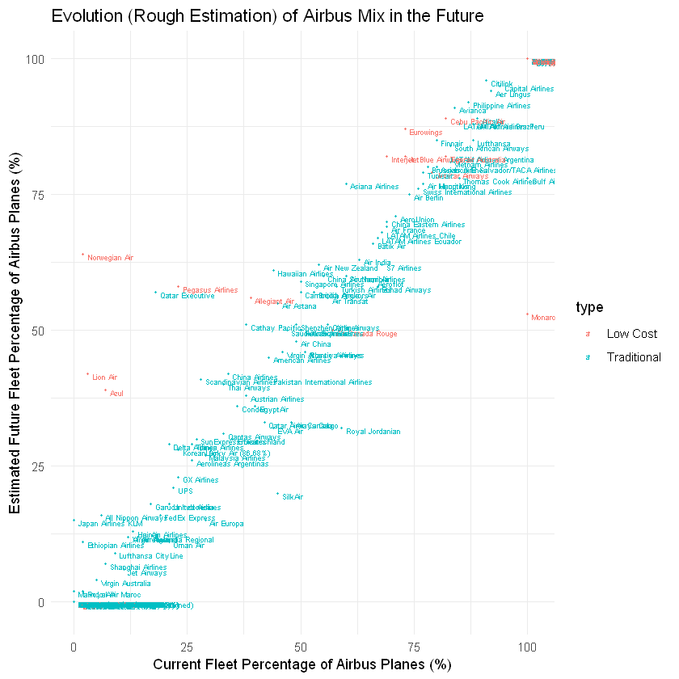

```r
ggplot(data=bycompany,aes(x=airbusper,y=newairbusper,label=airline,color=type))+geom_point(size=0.5)+geom_text(size=2,hjust=0,vjust=0,nudge_x=1,nudge_y=-1)+theme_minimal()+ggtitle("Evolution (Rough Estimation) of Airbus Mix in the Future")+labs(x="Current Fleet Percentage of Airbus Planes (%)")+labs(y="Estimated Future Fleet Percentage of Airbus Planes (%)")
```

##### Let's compare the two in terms of sales. Airbus and Boeing seem to have a duopoly. The third is a tenth of Boeing for instance.

```r
business <-data %>% filter(!is.na(orders)) %>% filter(orders>0) %>% group_by(plane_brand) %>% summarise(orders=sum(orders),cost=sum(newcost))

head(business %>% arrange(desc(cost)))
```

| plane_brand | orders | cost |
| --- | --- | --- |
| Airbus | 4665 | 669940 |
| Boeing | 3450 | 480513 |
| Embraer | 325 | 13424 |
| Bombardier | 186 | 12762 |
| Mitsubishi | 220 | 10340 |
| COMAC | 80 | 5440 |

#### I'm going to attempt PCA (principal component analysis) to convert observations to variables that may correlate into linearly uncorrelated variables called principal components.

##### This enables us to view whether airlines have diversity in their fleets. UA is mostly just Airbus and Boeing.

```
Standard deviations (1, .., p=7):
[1] 1.3342262 1.1528182 1.0588512 0.9712625 0.8330210 0.7772184 0.7268709

Rotation (n x k) = (7 x 7):
                   PC1         PC2         PC3        PC4        PC5        PC6
airbus      0.53826839 -0.02899423  0.20117794 -0.2047453  0.5405947 -0.4944229
boeing      0.60234086 -0.08737791  0.05479419 -0.1008275 -0.1733711  0.0719462
embraer    -0.10273959 -0.68126060  0.19173360  0.1278067  0.5056911  0.4587332
bombardier -0.07582006 -0.09804146 -0.58208725 -0.7781204  0.1322595  0.1511226
atr         0.04561279 -0.21516687 -0.71886429  0.5198873  0.1586036 -0.3504436
mcdonnell   0.54288640 -0.22079250 -0.18626712  0.1165498 -0.4020552  0.3761182
canadair   -0.18531688 -0.65019243  0.17168687 -0.2055252 -0.4665621 -0.5028119
                    PC7
airbus      0.300560456
boeing     -0.762330768
embraer    -0.077926528
bombardier -0.003409579
atr        -0.128872678
mcdonnell   0.552387916
canadair    0.026276718
```

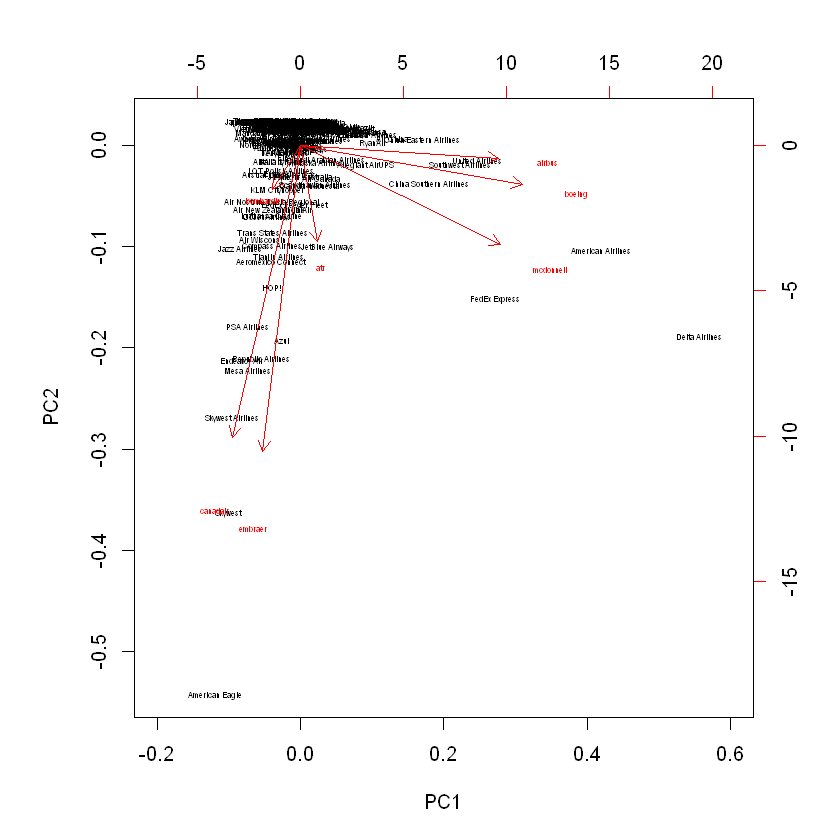

```r
fleets <- data %>% group_by(airline) %>% summarise(total=sum(current,na.rm=TRUE),airbus=sum(airbus),boeing=sum(boeing),embraer=sum(embraer),bombardier=sum(bombardier),atr=sum(atr),mcdonnell=sum(mcdonnell),canadair=sum(canadair))
#head(fleets)
#summary(fleets)
fleets<-as.data.frame(fleets)
row.names(fleets)<-fleets[,1]
fleets.pca <- prcomp(fleets[,3:ncol(fleets)],center=TRUE,scale=TRUE)
print(fleets.pca)
biplot(fleets.pca,cex=0.4,xlim=c(-0.2,0.6))
```

# Summary

###### We find that the largest existing fleets are US-based, the fastest growing airlines are low-cost carriers, most popular planes are cheaper, old ones like the 737. It seems like an overall trend towards Airbus, I have not yet started any of the stock price section though. I also need updated datasets. This one was provided by planespotters.com